# Diagnostic Testing and its Interpretation

Last week I was reading a twitter thread that talked about sensitivity/specificity of diagnostic tests (in the context of Covid) and how the diagnostic value varies with the prevalance of the disease in the general population. I spent sometime trying to understand the math behind the whole thing and here it is

## Definitions

Sensitivity or Recall = True posistives / Number of people with disease in sample

In other words, P(Test=Positive| Patient = Diseased)

Specificity = True Negatives / Number of people with no disease in sample

In other words, P(Test=Negative | Patient = Non-diseased)

Now, lets look at the False Positives. This is the set of people who do not have the disease, but the test shows them as having it.

In other words, P(Test=Positive | Patient = Non-diseased) = 1- P(Test=Negative | Patient = Nondiseased)

FPR = 1 - Specificity

## Interpreting Testing Results

Now, lets say the Test comes out positive. How woried should the person be that she actually has the disease. In other words, we need to determine

P(Patient=Diseased | Test=Positive) = P(Patient=Diseased ^ Test=Positive) / P(Test=Positive) = TP / (TP + FP)

In medical jargon, this is called Positive Predictive Value. Computer Scientists call it Precision.

Lets ask the other side of the question. How comfortable should a patient be, if the test comes out negative.

In other words, we need to estimate, P(Patient=Non-diseased | Test= Negative) = TN /(TN+FN)

In medical jargon, this quantity is called Negative Predictive Value.

Both positive and negative predictive values are functions of the test. However, their practical value depends on the prevalance of the disease as we will see next.

## Effect of Prevalance

Recall Precision = TP / (TP+FP)

Now, when there is low prevalance, TP tends to be small in the overall population. However, FP is determined by the specificity, in particular, (1 - specificity) of the test since a large section of the population is non-diseased. Consequently, unless the test has 100% specificity, a large number of FPs will show up, thereby reducing the precision or PPV. On the other hand, as the prevalance of the disease in the population goes up, a high sensitivity test will capture more of the diseased patients and FP tends to go down. As we can see in the graph belwo, PPV increases with prevalance.

A similar argument explains why NPV is high when prevalance is low since FN tends to be small when most of the pouplation is non diseased. On other hand, NPV goes down with increasing prealance, since the FNs now start dominating.

```r
sensitivity = 0.9
specificity = 0.8
prevalance_array=c(0.1,0.2,0.3,0.4,0.5,0.6,0.7,0.8,0.9)
ppv=c()
npv=c()
for (prevalance in prevalance_array){
  tp = sensitivity * prevalance
  fp = (1-specificity) * (1-prevalance)
  tn= (specificity) * (1-prevalance)
  fn= (1-sensitivity) * prevalance
  curr_ppv=tp/(tp+fp)
  curr_npv=tn/(tn+fn)

  ppv <- append(ppv,curr_ppv)
  npv <- append(npv,curr_npv)
}
ppv
```

```
## [1] 0.3333333 0.5294118 0.6585366 0.7500000 0.8181818 0.8709677 0.9130435
## [8] 0.9473684 0.9759036
```

```r
npv
```

```
## [1] 0.9863014 0.9696970 0.9491525 0.9230769 0.8888889 0.8421053 0.7741935
## [8] 0.6666667 0.4705882
```

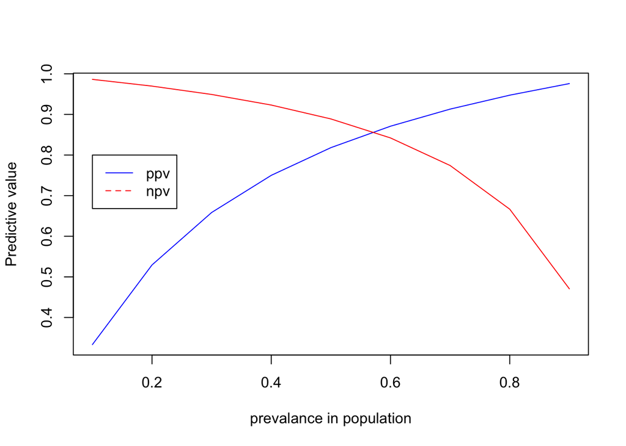

```r
plot(prevalance_array,ppv,type="l",col="blue",ylab="Predictive value",xlab="prevalance in population")
lines(prevalance_array,npv,type="l",col="red")
legend(0.1,0.8,legend=c("ppv","npv"),col=c("blue","red"),lty=1:2)
```